# PDSI_final

AnnaClaire Marley

8/2/2019

Finalized version of the PDSI markdwon

## Whole Navajo Nation

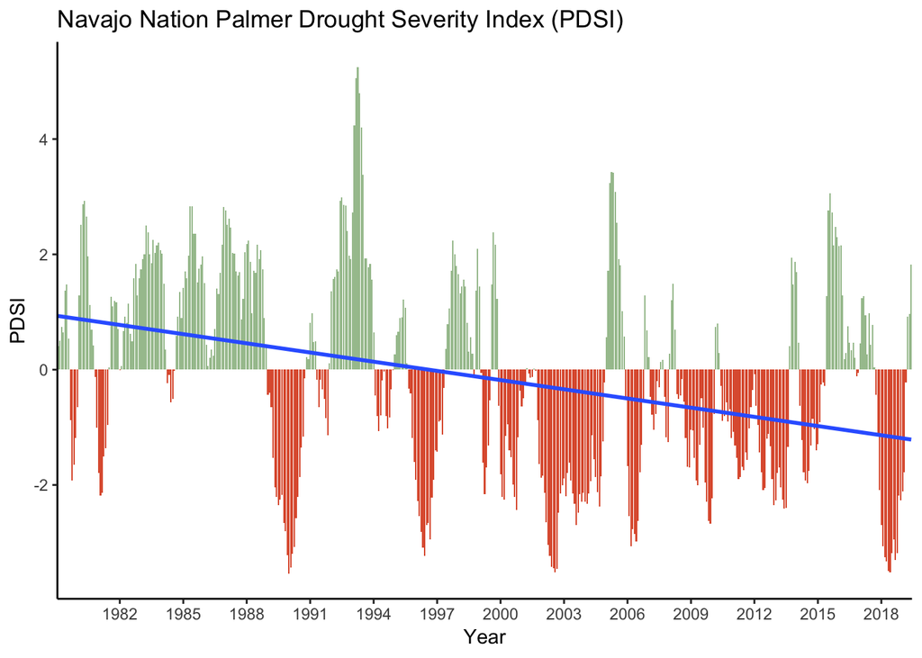

```
##
## Call:
## lm(formula = nn_mnth_pdsi$pdsi ~ nn_mnth_pdsi$date)
##
## Residuals:
##     Min      1Q  Median      3Q     Max
## -3.8867 -1.2088 -0.0772  1.2816  5.0680
##
## Coefficients:
##                     Estimate Std. Error t value Pr(>|t|)
## (Intercept)        1.414e+00  2.046e-01   6.908 1.55e-11 ***
## nn_mnth_pdsi$date -1.455e-04  1.779e-05  -8.179 2.55e-15 ***
## ---
## Signif. codes:  0 '***' 0.001 '**' 0.01 '*' 0.05 '.' 0.1 ' ' 1
##
## Residual standard error: 1.67 on 483 degrees of freedom
## Multiple R-squared:  0.1216, Adjusted R-squared:  0.1198
## F-statistic: 66.89 on 1 and 483 DF,  p-value: 2.552e-15
```

- 1980s appeared to be more wet and then starting in 2000 there is a tendency to be in drought

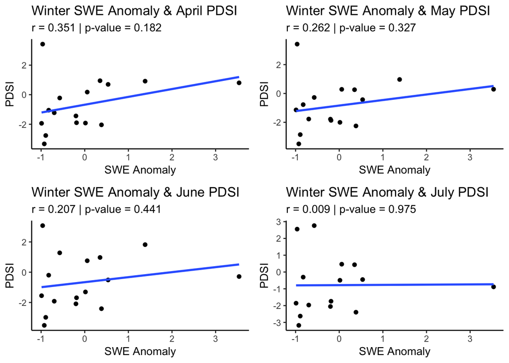

- High elevation winter swe anomaly is most correlated to Navajo Nation April PDSI
- the statistical significance isnt great for any of the correlations though

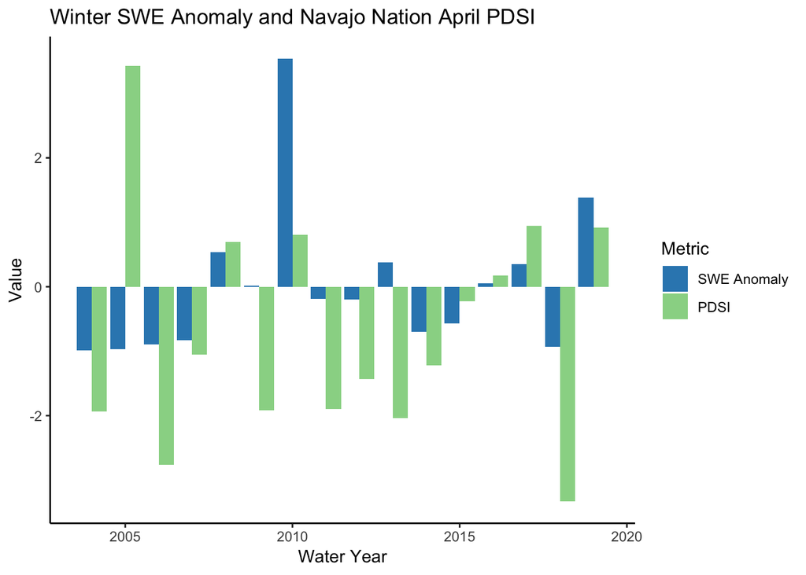

- *April* positive swe & positive spi / positive swe: 71.429%
- *April* negative swe & negative spi / negative swe: 88.8888889%
- *April* total same sign: 81.25%

## Agencies

#### Correlation of PDSI monthly averages for the Agencies

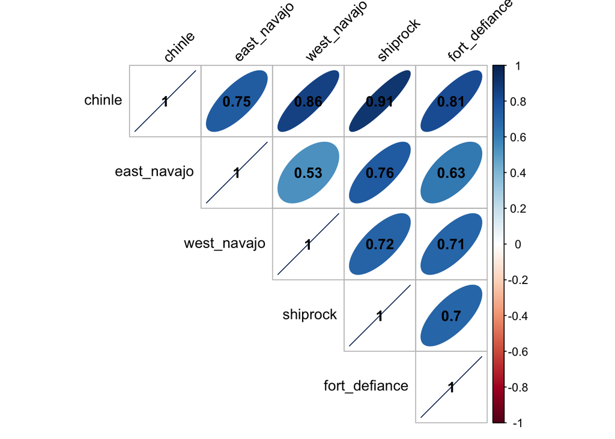

### Correlation between high elevation winter swe anomaly and the monthly average PDSI of the agencies

#### April SPI & All Mts Winter Swe Anomaly

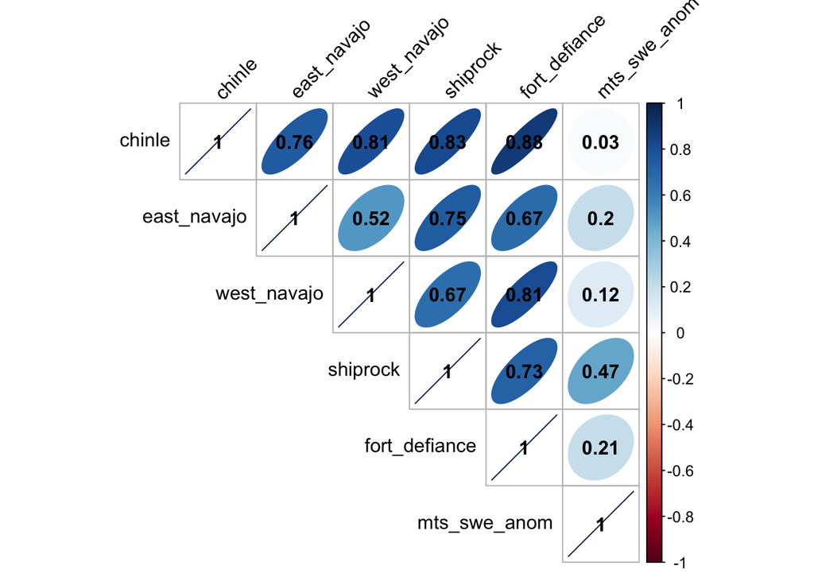

- Shiprock PDSI seems to be most correlated high elevation winter swe anomaly

### Correlation between Chuska winter swe anomaly and the monthly average PDSI of the agencies

#### April SPI and Chuska SWE Winter Anomaly

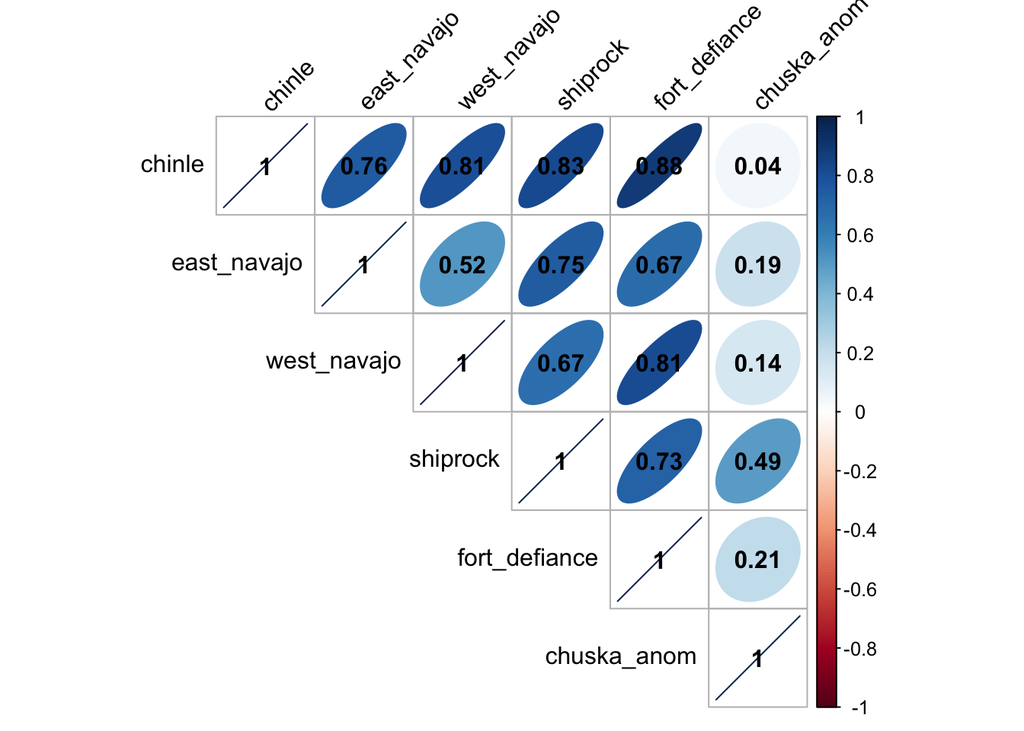

- Shiprocks April PDSI is most correlated to CHuska winter swe anomaly

## Watersheds

#### Watershed PDSI timeseries (1981-present)

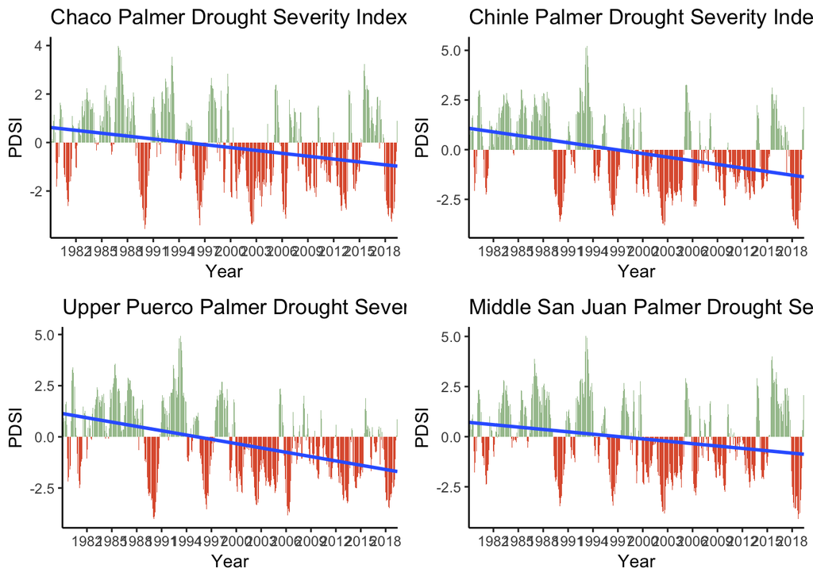

- all of the watersheds show increasing drought towards the 21st century

#### Watershed PDSI vs Chuska winter swe anomaly

##### April PDSI

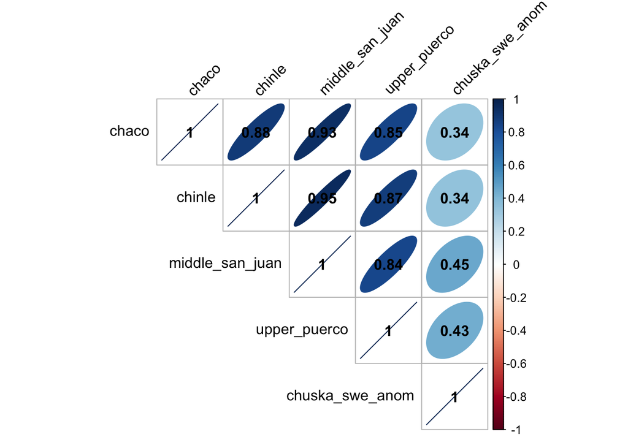

- Middle San Juan April PDSI has the highest correlation to Chuska winter swe anomaly

##### Middle San Juan April PDSI andC huska winter swe anomaly

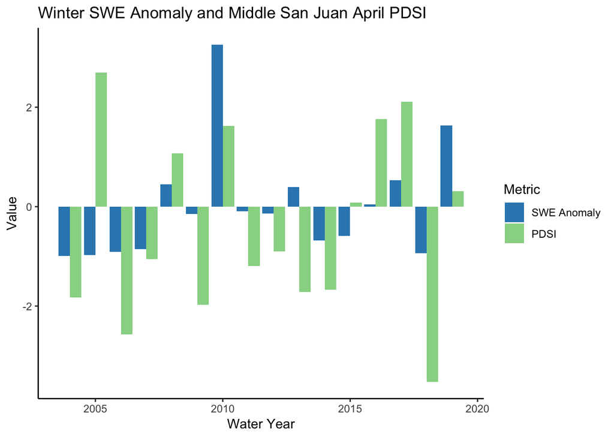

- *April* positive swe & positive spi / positive swe: 83.333%
- *April* negative swe & negative spi / negative swe: 80%
- *April* total correct: 81.25%

##### May

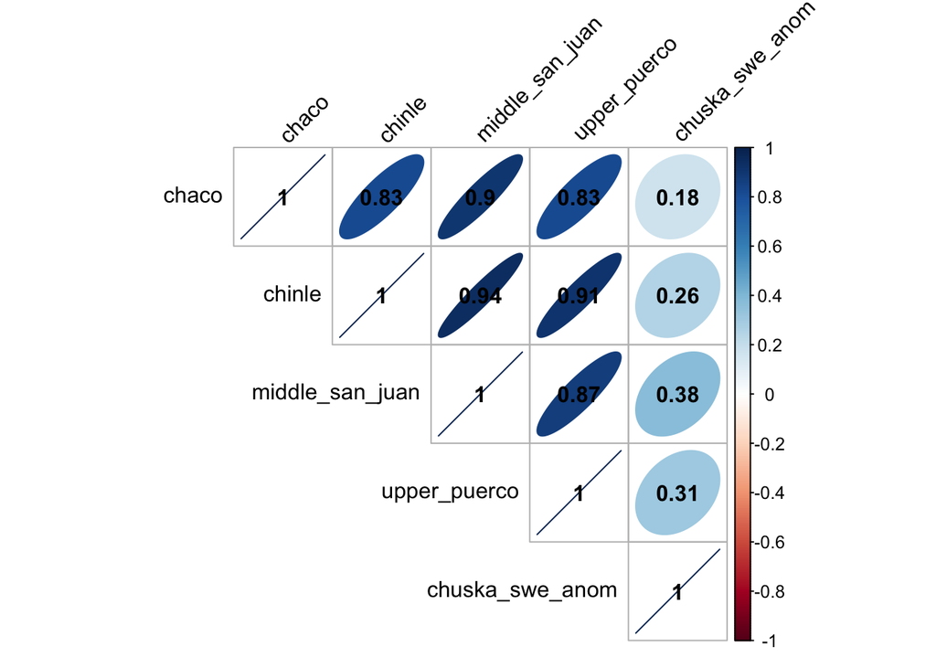

- for May PDSI, middle san juan is still most highly correlated to winter swe anomaly
- Watersheds’ PDSI seem to be most highly correlated to winter swe anomaly in April

### Chuska winter swe and watershed PDSI AMJ

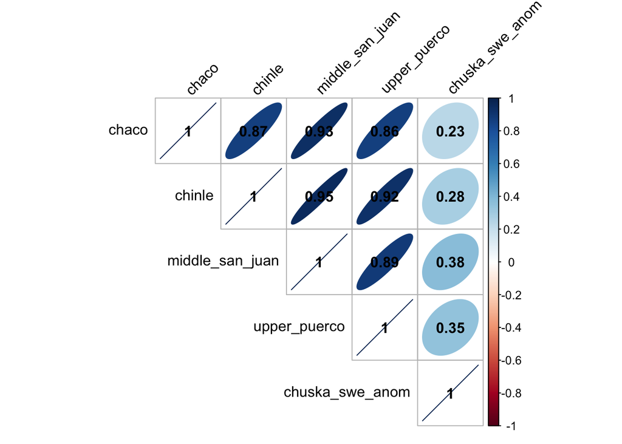

### Chuska winter swe and watershed PDSI December - May (6 month PDSI)

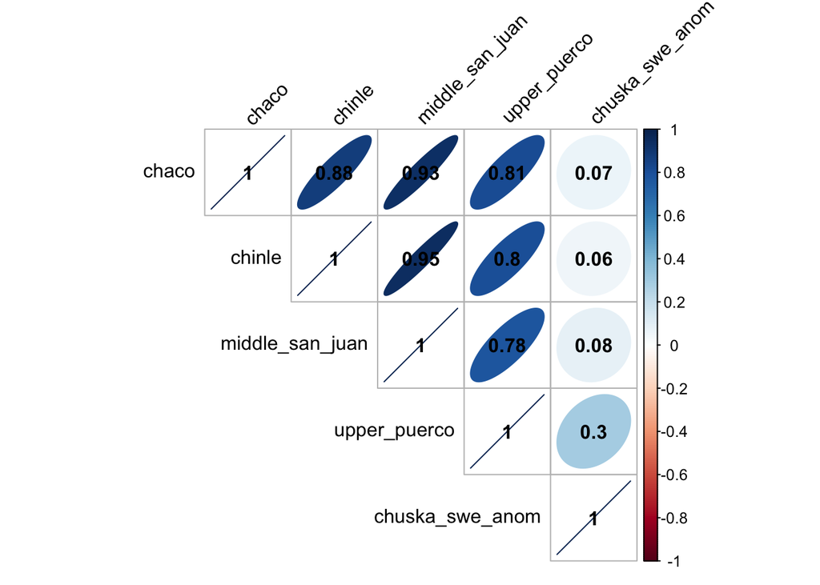

- not really correlated at all

### Chuska winter swe and watershed PDSI January - June (6 month PDSI)

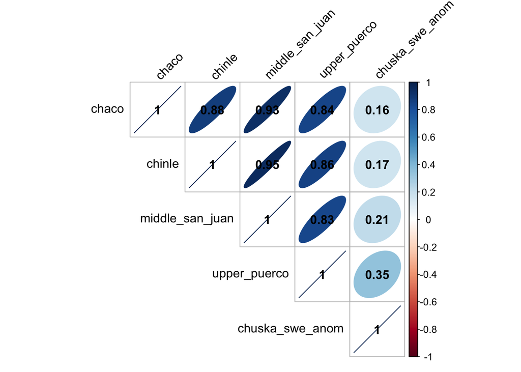

- a bit more highly correlated than Dec-May

### Tsaile Chapter

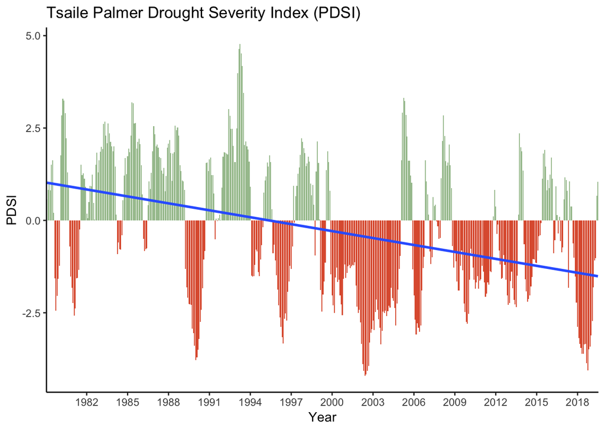

```
##
## Call:
## lm(formula = tsaile_pdsi_mnth$pdsi ~ tsaile_pdsi_mnth$date)
##
## Residuals:
##     Min      1Q  Median      3Q     Max
## -4.1174 -1.3595  0.0247  1.4272  4.6402
##
## Coefficients:
##                         Estimate Std. Error t value Pr(>|t|)
## (Intercept)            1.588e+00  2.181e-01   7.282 1.34e-12 ***
## tsaile_pdsi_mnth$date -1.714e-04  1.894e-05  -9.053  < 2e-16 ***
## ---
## Signif. codes:  0 '***' 0.001 '**' 0.01 '*' 0.05 '.' 0.1 ' ' 1
##
## Residual standard error: 1.783 on 484 degrees of freedom
##   (1 observation deleted due to missingness)
## Multiple R-squared:  0.1448, Adjusted R-squared:  0.143
## F-statistic: 81.95 on 1 and 484 DF,  p-value: < 2.2e-16
```

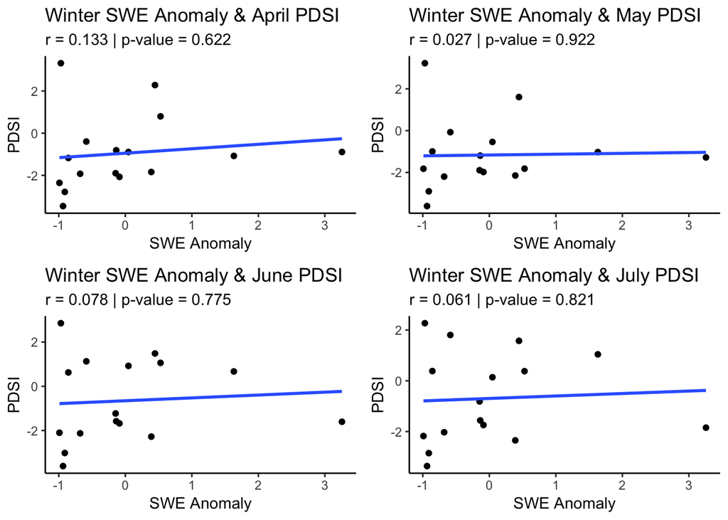

- Tsaile PDSI doesnt really ever seem to be correlated with Chuska winter swe anomaly

##### Tsaile April PDSI andC huska winter swe anomaly

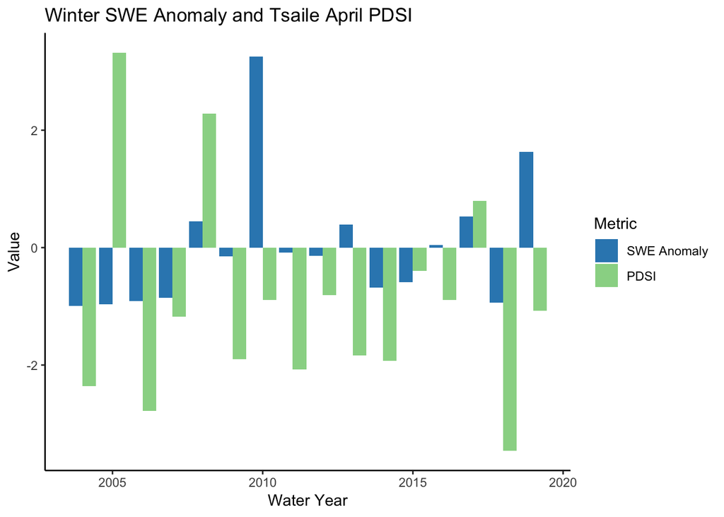

- *April* positive swe & positive spi / positive swe: 33.333%
- *April* negative swe & negative spi / negative swe: 90%
- *April* total correct: 68.75%

But Tsaile PDSI is almost consistently always negative, so be careful about interpreting the effect of SWE here